# Titanic - Data Analysis Project

### Seems like Pclass 3 has very less Survival percentage compared to others

```python
#Add a column to see whether the passenger with Family or Alone
titanic_df['Family'] = titanic_df['SibSp'] + titanic_df['Parch']
```

```python
titanic_df.head()
```

|  | PassengerId | Survived | Pclass | Name | Sex | Age | SibSp | Parch | Ticket | Fare | Cabin | Embarked | Salutation | new_age | person_type | Family |
| --- | --- | --- | --- | --- | --- | --- | --- | --- | --- | --- | --- | --- | --- | --- | --- | --- |
| 0 | 1 | 0 | 3 | Braund, Mr. Owen Harris | male | 22.0 | 1 | 0 | A/5 21171 | 7.2500 | NaN | S | Mr | 22.0 | male | 1 |
| 1 | 2 | 1 | 1 | Cumings, Mrs. John Bradley (Florence Briggs Th... | female | 38.0 | 1 | 0 | PC 17599 | 71.2833 | C85 | C | Mrs | 38.0 | female | 1 |
| 2 | 3 | 1 | 3 | Heikkinen, Miss. Laina | female | 26.0 | 0 | 0 | STON/O2. 3101282 | 7.9250 | NaN | S | Miss | 26.0 | female | 0 |
| 3 | 4 | 1 | 1 | Futrelle, Mrs. Jacques Heath (Lily May Peel) | female | 35.0 | 1 | 0 | 113803 | 53.1000 | C123 | S | Mrs | 35.0 | female | 1 |
| 4 | 5 | 0 | 3 | Allen, Mr. William Henry | male | 35.0 | 0 | 0 | 373450 | 8.0500 | NaN | S | Mr | 35.0 | male | 0 |

```python
titanic_df['Family'].loc[titanic_df['Family'] > 0] = 'With Family'
titanic_df['Family'].loc[titanic_df['Family'] == 0] = 'Alone'
```

```python
titanic_df.head()
```

|  | PassengerId | Survived | Pclass | Name | Sex | Age | SibSp | Parch | Ticket | Fare | Cabin | Embarked | Salutation | new_age | person_type | Family |
| --- | --- | --- | --- | --- | --- | --- | --- | --- | --- | --- | --- | --- | --- | --- | --- | --- |
| 0 | 1 | 0 | 3 | Braund, Mr. Owen Harris | male | 22.0 | 1 | 0 | A/5 21171 | 7.2500 | NaN | S | Mr | 22.0 | male | With Family |
| 1 | 2 | 1 | 1 | Cumings, Mrs. John Bradley (Florence Briggs Th... | female | 38.0 | 1 | 0 | PC 17599 | 71.2833 | C85 | C | Mrs | 38.0 | female | With Family |
| 2 | 3 | 1 | 3 | Heikkinen, Miss. Laina | female | 26.0 | 0 | 0 | STON/O2. 3101282 | 7.9250 | NaN | S | Miss | 26.0 | female | Alone |
| 3 | 4 | 1 | 1 | Futrelle, Mrs. Jacques Heath (Lily May Peel) | female | 35.0 | 1 | 0 | 113803 | 53.1000 | C123 | S | Mrs | 35.0 | female | With Family |
| 4 | 5 | 0 | 3 | Allen, Mr. William Henry | male | 35.0 | 0 | 0 | 373450 | 8.0500 | NaN | S | Mr | 35.0 | male | Alone |

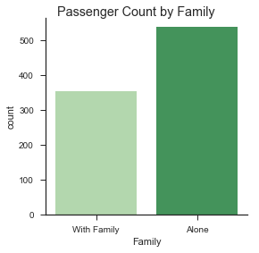

```python
#Creaate plot to see Passenger count by Family or Alone
sns.factorplot('Family',kind= 'count', data=titanic_df,palette = 'Greens')
sns.plt.suptitle('Passenger Count by Family')
# this plot sows the Passengers with family and not in Titanic and will answer our Question 3.
```

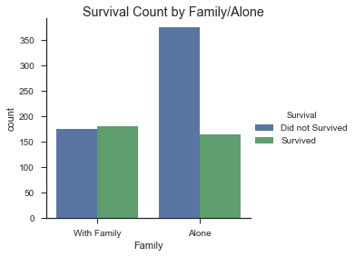

```python
#Create to plot to see the count by Family / Alone with Survival Status
sns.factorplot('Family', data = titanic_df, kind = 'count', hue = 'Survival', legend = True)
sns.plt.suptitle('Survival Count by Family/Alone')
```

So percentage of getting survived is less for who are all alone

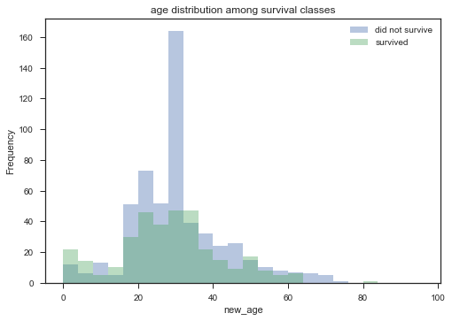

```python
#Create plot to Survival by Age Distribution
age_bins = np.arange(0, 100, 4)
sns.distplot(titanic_df.loc[(titanic_df['Survived']==0),'new_age'], bins=age_bins, kde=False)
sns.distplot(titanic_df.loc[(titanic_df['Survived']==1),'new_age'], bins=age_bins,kde=False)
plt.title('age distribution among survival classes')
plt.ylabel('Frequency')
plt.legend(['did not survive', 'survived'])
```

Looks like the survial rate for Child is more

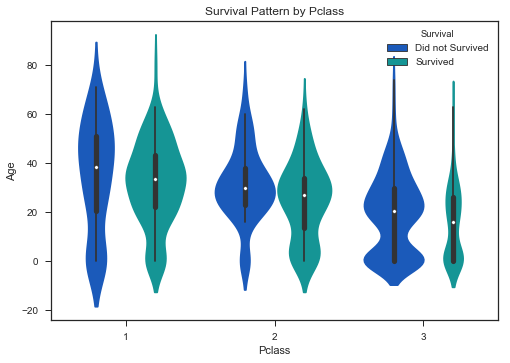

```python
#Create plot to see the Survival pattern by PClass
g = sns.violinplot(x= 'Pclass', y ='Age',data=titanic_df,palette='winter', scale = 'count', hue = 'Survival')
sns.plt.title('Survival Pattern by Pclass')
```

The Survival percentage for PClass3 seems to be very low

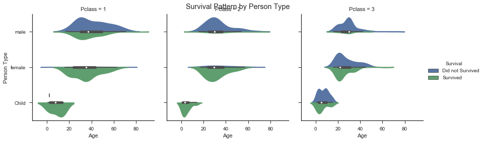

```python
#Create plot to see the Survival Pattern by Pclass and Person Type
g = sns.factorplot(x='new_age', y ='person_type', hue = 'Survival', data=titanic_df, kind='violin', split = True, col = 'Pclass', scale= 'count')
sns.plt.suptitle('Survival Pattern by Person Type')
g.set_axis_labels("Age", "Person Type")
```

ok, male passengers in PClass 2 and 3 are very less likely to Survive. And Female or Child Passengers in PClass 1 and 2 are mostly survived.

## Conclusion:

- Based on our analysis on the sample data, it seems like Survival rate is less for Male Passengers,Lower class and Passengers travelling alone
- Child and Females in PClass 1 and 2 are most likely to be survived
- As this a sample set of data, there may be a slight difference for the whole data, we only have around 70% of total data
- As we saw initially most of the Cabin data are not available, and from our other analysis Passenger Class 3 has less survival rate. So if we had much data in Cabin it will give opportunities to analyze more in Pclass 3 itself and get some inisights
- Also there were some Age data missing which we filled wiith Median, it can make a small impact if we had all Age data